# **PHASE_1- Data Exploration & Initial Assessment**

```python
import pandas as pd
import numpy as np
import os
```

### Loading the Dataset

```python
df = pd.read_csv(r"C:/Datasets/hotel_booking.csv")
```

#### Observation:

- Dataset has been loaded successfully using pd.read_csv()

### Understanding the Structure of the Dataset

```python
df.shape
```

```
(119390, 36)
```

#### Observation:

The dataset contains **119,390 rows** (records) and **36 columns** (features), making it a **large dataset suitable for detailed analysis and modeling**.

### Previewing the first few rows

```python
df.head()
```

|  | hotel | is_canceled | lead_time | arrival_date_year | arrival_date_month | arrival_date_week_number | arrival_date_day_of_month | stays_in_weekend_nights | stays_in_week_nights | adults | ... | customer_type | adr | required_car_parking_spaces | total_of_special_requests | reservation_status | reservation_status_date | name | email | phone-number | credit_card |
| --- | --- | --- | --- | --- | --- | --- | --- | --- | --- | --- | --- | --- | --- | --- | --- | --- | --- | --- | --- | --- | --- |
| 0 | Resort Hotel | 0 | 342 | 2015 | July | 27 | 1 | 0 | 0 | 2 | ... | Transient | 0.0 | 0 | 0 | Check-Out | 2015-07-01 | Ernest Barnes | Ernest.Barnes31@outlook.com | 669-792-1661 | ************4322 |
| 1 | Resort Hotel | 0 | 737 | 2015 | July | 27 | 1 | 0 | 0 | 2 | ... | Transient | 0.0 | 0 | 0 | Check-Out | 2015-07-01 | Andrea Baker | Andrea_Baker94@aol.com | 858-637-6955 | ************9157 |
| 2 | Resort Hotel | 0 | 7 | 2015 | July | 27 | 1 | 0 | 1 | 1 | ... | Transient | 75.0 | 0 | 0 | Check-Out | 2015-07-02 | Rebecca Parker | Rebecca_Parker@comcast.net | 652-885-2745 | ************3734 |
| 3 | Resort Hotel | 0 | 13 | 2015 | July | 27 | 1 | 0 | 1 | 1 | ... | Transient | 75.0 | 0 | 0 | Check-Out | 2015-07-02 | Laura Murray | Laura_M@gmail.com | 364-656-8427 | ************5677 |
| 4 | Resort Hotel | 0 | 14 | 2015 | July | 27 | 1 | 0 | 2 | 2 | ... | Transient | 98.0 | 0 | 1 | Check-Out | 2015-07-03 | Linda Hines | LHines@verizon.com | 713-226-5883 | ************5498 |

5 rows × 36 columns

#### Observation:

The first five rows show that the dataset records **individual hotel bookings** with detailed customer and reservation information. Key columns include booking details (e.g., `hotel`, `arrival_date_year`, `lead_time`), stay details (e.g., `stays_in_weekend_nights`, `adr`), and guest details (e.g., `name`, `email`, `credit_card`). The data is well-structured, with both categorical and numerical features, making it rich for analysis such as customer segmentation, cancellation prediction, and trend insights.

### Dataset Structure and Data Types

```python
df.info()
```

```
<class 'pandas.core.frame.DataFrame'>
RangeIndex: 119390 entries, 0 to 119389
Data columns (total 36 columns):
 #   Column                          Non-Null Count   Dtype
---  ------                          --------------   -----
 0   hotel                           119390 non-null  object
 1   is_canceled                     119390 non-null  int64
 2   lead_time                       119390 non-null  int64
 3   arrival_date_year               119390 non-null  int64
 4   arrival_date_month              119390 non-null  object
 5   arrival_date_week_number        119390 non-null  int64
 6   arrival_date_day_of_month       119390 non-null  int64
 7   stays_in_weekend_nights         119390 non-null  int64
 8   stays_in_week_nights            119390 non-null  int64
 9   adults                          119390 non-null  int64
```

[output cut: 28 more lines]

#### Observation:

The dataset contains **119,390 entries and 36 columns** with a mix of **numerical (int64, float64)** and **categorical (object)** data types. Most columns are complete, but there are **missing values** in `children` (4 missing), `country` (~488 missing), `agent` (~13.6% missing), and `company` (~94% missing). The dataset size is **32.8 MB**, and due to its diversity in data types, it is suitable for both **descriptive analytics and predictive modeling**, but requires handling of missing values and categorical encoding.

### Statistical Overview of Numerical Data

```python
df.describe()
```

|  | is_canceled | lead_time | arrival_date_year | arrival_date_week_number | arrival_date_day_of_month | stays_in_weekend_nights | stays_in_week_nights | adults | children | babies | is_repeated_guest | previous_cancellations | previous_bookings_not_canceled | booking_changes | agent | company | days_in_waiting_list | adr | required_car_parking_spaces | total_of_special_requests |
| --- | --- | --- | --- | --- | --- | --- | --- | --- | --- | --- | --- | --- | --- | --- | --- | --- | --- | --- | --- | --- |
| count | 119390.000000 | 119390.000000 | 119390.000000 | 119390.000000 | 119390.000000 | 119390.000000 | 119390.000000 | 119390.000000 | 119386.000000 | 119390.000000 | 119390.000000 | 119390.000000 | 119390.000000 | 119390.000000 | 103050.000000 | 6797.000000 | 119390.000000 | 119390.000000 | 119390.000000 | 119390.000000 |
| mean | 0.370416 | 104.011416 | 2016.156554 | 27.165173 | 15.798241 | 0.927599 | 2.500302 | 1.856403 | 0.103890 | 0.007949 | 0.031912 | 0.087118 | 0.137097 | 0.221124 | 86.693382 | 189.266735 | 2.321149 | 101.831122 | 0.062518 | 0.571363 |
| std | 0.482918 | 106.863097 | 0.707476 | 13.605138 | 8.780829 | 0.998613 | 1.908286 | 0.579261 | 0.398561 | 0.097436 | 0.175767 | 0.844336 | 1.497437 | 0.652306 | 110.774548 | 131.655015 | 17.594721 | 50.535790 | 0.245291 | 0.792798 |
| min | 0.000000 | 0.000000 | 2015.000000 | 1.000000 | 1.000000 | 0.000000 | 0.000000 | 0.000000 | 0.000000 | 0.000000 | 0.000000 | 0.000000 | 0.000000 | 0.000000 | 1.000000 | 6.000000 | 0.000000 | -6.380000 | 0.000000 | 0.000000 |
| 25% | 0.000000 | 18.000000 | 2016.000000 | 16.000000 | 8.000000 | 0.000000 | 1.000000 | 2.000000 | 0.000000 | 0.000000 | 0.000000 | 0.000000 | 0.000000 | 0.000000 | 9.000000 | 62.000000 | 0.000000 | 69.290000 | 0.000000 | 0.000000 |
| 50% | 0.000000 | 69.000000 | 2016.000000 | 28.000000 | 16.000000 | 1.000000 | 2.000000 | 2.000000 | 0.000000 | 0.000000 | 0.000000 | 0.000000 | 0.000000 | 0.000000 | 14.000000 | 179.000000 | 0.000000 | 94.575000 | 0.000000 | 0.000000 |
| 75% | 1.000000 | 160.000000 | 2017.000000 | 38.000000 | 23.000000 | 2.000000 | 3.000000 | 2.000000 | 0.000000 | 0.000000 | 0.000000 | 0.000000 | 0.000000 | 0.000000 | 229.000000 | 270.000000 | 0.000000 | 126.000000 | 0.000000 | 1.000000 |
| max | 1.000000 | 737.000000 | 2017.000000 | 53.000000 | 31.000000 | 19.000000 | 50.000000 | 55.000000 | 10.000000 | 10.000000 | 1.000000 | 26.000000 | 72.000000 | 21.000000 | 535.000000 | 543.000000 | 391.000000 | 5400.000000 | 8.000000 | 5.000000 |

#### Observation:

- **Rows:** 119,390 total entries
- **Lead Time:** Avg ~104 days, max ~737 → many book far in advance
- **Stay Duration:** Avg 3–4 nights, but outliers up to ~70 nights
- **Guests:** Mostly 1–2 adults; children/babies are rare, some invalid (0 adults)
- **ADR (Price):** Avg ~100, extreme outliers up to 5400
- **Special Requests:** Typically none or 1; max of 5
- **Repeat Guests:** Very low → hotels rely mostly on new customers

### Null Value Count Across All Columns¶

```python
df.isnull().sum()
```

```
hotel                                  0
is_canceled                            0
lead_time                              0
arrival_date_year                      0
arrival_date_month                     0
arrival_date_week_number               0
arrival_date_day_of_month              0
stays_in_weekend_nights                0
stays_in_week_nights                   0
adults                                 0
children                               4
babies                                 0
meal                                   0
country                              488
market_segment                         0
distribution_channel                   0
is_repeated_guest                      0
previous_cancellations                 0
previous_bookings_not_canceled         0
reserved_room_type                     0
assigned_room_type                     0
booking_changes                        0
deposit_type                           0
agent                              16340
company                           112593
days_in_waiting_list                   0
customer_type                          0
adr                                    0
required_car_parking_spaces            0
total_of_special_requests              0
reservation_status                     0
reservation_status_date                0
name                                   0
email                                  0
phone-number                           0
credit_card                            0
dtype: int64
```

#### Observation:

Most columns have no missing values, but `children` has **4** missing and `country` has **488** missing. `agent` has **16,340** missing values, while `company` has **112,593** missing values (almost all).

### Null value Analysis

```python
df.isnull()
```

|  | hotel | is_canceled | lead_time | arrival_date_year | arrival_date_month | arrival_date_week_number | arrival_date_day_of_month | stays_in_weekend_nights | stays_in_week_nights | adults | ... | customer_type | adr | required_car_parking_spaces | total_of_special_requests | reservation_status | reservation_status_date | name | email | phone-number | credit_card |
| --- | --- | --- | --- | --- | --- | --- | --- | --- | --- | --- | --- | --- | --- | --- | --- | --- | --- | --- | --- | --- | --- |
| 0 | False | False | False | False | False | False | False | False | False | False | ... | False | False | False | False | False | False | False | False | False | False |
| 1 | False | False | False | False | False | False | False | False | False | False | ... | False | False | False | False | False | False | False | False | False | False |
| 2 | False | False | False | False | False | False | False | False | False | False | ... | False | False | False | False | False | False | False | False | False | False |
| 3 | False | False | False | False | False | False | False | False | False | False | ... | False | False | False | False | False | False | False | False | False | False |
| 4 | False | False | False | False | False | False | False | False | False | False | ... | False | False | False | False | False | False | False | False | False | False |
| ... | ... | ... | ... | ... | ... | ... | ... | ... | ... | ... | ... | ... | ... | ... | ... | ... | ... | ... | ... | ... | ... |
| 119385 | False | False | False | False | False | False | False | False | False | False | ... | False | False | False | False | False | False | False | False | False | False |
| 119386 | False | False | False | False | False | False | False | False | False | False | ... | False | False | False | False | False | False | False | False | False | False |
| 119387 | False | False | False | False | False | False | False | False | False | False | ... | False | False | False | False | False | False | False | False | False | False |
| 119388 | False | False | False | False | False | False | False | False | False | False | ... | False | False | False | False | False | False | False | False | False | False |
| 119389 | False | False | False | False | False | False | False | False | False | False | ... | False | False | False | False | False | False | False | False | False | False |

119390 rows × 36 columns

### Percentage of Missing Values

```python
round(df.isnull().sum()/len(df)*100,2)
```

```
hotel                              0.00
is_canceled                        0.00
lead_time                          0.00
arrival_date_year                  0.00
arrival_date_month                 0.00
arrival_date_week_number           0.00
arrival_date_day_of_month          0.00
stays_in_weekend_nights            0.00
stays_in_week_nights               0.00
adults                             0.00
children                           0.00
babies                             0.00
meal                               0.00
country                            0.41
market_segment                     0.00
distribution_channel               0.00
is_repeated_guest                  0.00
previous_cancellations             0.00
previous_bookings_not_canceled     0.00
reserved_room_type                 0.00
assigned_room_type                 0.00
booking_changes                    0.00
deposit_type                       0.00
agent                             13.69
company                           94.31
days_in_waiting_list               0.00
customer_type                      0.00
adr                                0.00
required_car_parking_spaces        0.00
total_of_special_requests          0.00
reservation_status                 0.00
reservation_status_date            0.00
name                               0.00
email                              0.00
phone-number                       0.00
credit_card                        0.00
dtype: float64
```

#### Observation:

- children → 0.00% (negligible)
- country → 0.41% (very small)
- agent → 13.69% (moderate missing)
- company → 94.31% (almost all missing)
- All other columns → 0.00% missing

```python
df.info()
```

```
<class 'pandas.core.frame.DataFrame'>
RangeIndex: 119390 entries, 0 to 119389
Data columns (total 36 columns):
 #   Column                          Non-Null Count   Dtype
---  ------                          --------------   -----
 0   hotel                           119390 non-null  object
 1   is_canceled                     119390 non-null  int64
 2   lead_time                       119390 non-null  int64
 3   arrival_date_year               119390 non-null  int64
 4   arrival_date_month              119390 non-null  object
 5   arrival_date_week_number        119390 non-null  int64
 6   arrival_date_day_of_month       119390 non-null  int64
 7   stays_in_weekend_nights         119390 non-null  int64
 8   stays_in_week_nights            119390 non-null  int64
 9   adults                          119390 non-null  int64
```

[output cut: 28 more lines]

### Value Count Summary (Hotel Booking Dataset)

1. **Hotel**
   - Type of hotel booked (e.g., City Hotel, Resort Hotel).
   - No missing values (119,390 records complete).
2. **Is Canceled**
   - Indicates whether the booking was canceled (1) or not (0).
   - No missing values.
3. **Lead Time**
   - Number of days between booking date and arrival date.
   - Complete (no missing).
4. **Arrival Date (Year, Month, Week Number, Day of Month)**
   - Captures detailed arrival time of the guest.
   - All complete, no missing data.
5. **Stays in Weekend Nights**
   - Nights spent during weekends.
   - No missing values.
6. **Stays in Week Nights**
   - Nights spent during weekdays.
   - No missing values.
7. **Adults**
   - Number of adults in the booking.
   - Complete (no missing).
8. **Children**
   - Number of children included.
   - Slightly missing (4 records missing).
9. **Babies**
   - Number of babies included.
   - Complete (no missing).
10. **Meal**
- Type of meal plan chosen (e.g., BB, FB, HB).
- No missing values.
11. **Country**
- Guest’s country of origin.
- 488 missing values.
12. **Market Segment**
- Booking market source (e.g., Online TA, Direct, Corporate).
- No missing values.
13. **Distribution Channel**
- Channel through which the booking was made.
- No missing values.
14. **Is Repeated Guest**
- Indicates if the guest has booked previously.
- No missing values.
15. **Previous Cancellations**
- Number of past bookings that were canceled by the customer.
- Complete.
16. **Previous Bookings Not Canceled**
- Number of past bookings not canceled.
- Complete.
17. **Reserved Room Type**
- Type of room reserved.
- No missing values.
18. **Assigned Room Type**
- Type of room assigned.
- No missing values.
19. **Booking Changes**
- Number of changes made to the booking.
- No missing values.
20. **Deposit Type**
- Indicates if a deposit was required (No Deposit, Non Refund, Refundable).
- No missing values.
21. **Agent**
- ID of the booking agent.
- 16,340 missing values.
22. **Company**
- ID of the company that made the booking.
- Highly missing (112,593 missing).
23. **Days in Waiting List**
- Number of days the booking was on the waiting list.
- Complete.
24. **Customer Type**
- Type of customer (e.g., Contract, Transient, Group).
- No missing values.
25. **ADR (Average Daily Rate)**
- Average rate per night in the booking.
- No missing values.
26. **Required Car Parking Spaces**
- Number of car parking spaces requested.
- No missing values.
27. **Total of Special Requests**
- Number of special requests made.
- Complete.
28. **Reservation Status**
- Status of the reservation (e.g., Canceled, Check-Out, No-Show).
- No missing values.
29. **Reservation Status Date**
- Date at which the last status was set.
- No missing values.
30. **Name**
- Guest’s full name.
- Complete.
31. **Email**
- Guest’s email address.
- Complete.
32. **Phone Number**
- Guest’s phone number.
- Complete.
33. **Credit Card**
- Guest’s credit card number (masked/anonymized).
- No missing values.

```python
df["hotel"].value_counts()
```

```
hotel
City Hotel      79330
Resort Hotel    40060
Name: count, dtype: int64
```

```python
df['meal'].value_counts()
```

```
meal
BB           92310
HB           14463
SC           10650
Undefined     1169
FB             798
Name: count, dtype: int64
```

```python
df['market_segment'].value_counts()
```

```
market_segment
Online TA        56477
Offline TA/TO    24219
Groups           19811
Direct           12606
Corporate         5295
Complementary      743
Aviation           237
Undefined            2
Name: count, dtype: int64
```

```python
df['distribution_channel'].value_counts()
```

```
distribution_channel
TA/TO        97870
Direct       14645
Corporate     6677
GDS            193
Undefined        5
Name: count, dtype: int64
```

```python
df['reserved_room_type'].value_counts()
```

```
reserved_room_type
A    85994
D    19201
E     6535
F     2897
G     2094
B     1118
C      932
H      601
P       12
L        6
Name: count, dtype: int64
```

```python
df['assigned_room_type'].value_counts()
```

```
assigned_room_type
A    74053
D    25322
E     7806
F     3751
G     2553
C     2375
B     2163
H      712
I      363
K      279
P       12
L        1
Name: count, dtype: int64
```

```python
df['deposit_type'].value_counts()
```

```
deposit_type
No Deposit    104641
Non Refund     14587
Refundable       162
Name: count, dtype: int64
```

```python
df['customer_type'].value_counts()
```

```
customer_type
Transient          89613
Transient-Party    25124
Contract            4076
Group                577
Name: count, dtype: int64
```

```python
df['country'].value_counts()
```

```
country
PRT    48590
GBR    12129
FRA    10415
ESP     8568
DEU     7287
       ...
DJI        1
BWA        1
HND        1
VGB        1
NAM        1
Name: count, Length: 177, dtype: int64
```

```python
df['arrival_date_year'].value_counts()
```

```
arrival_date_year
2016    56707
2017    40687
2015    21996
Name: count, dtype: int64
```

#### 1. How many bookings are in the dataset?

```python
len(df)
```

```
119390
```

#### Observation:

The dataset comprises `119,390 bookings`, providing a sufficiently large sample to analyze diverse booking behaviors across hotel types, customer segments, and seasonal trends.

#### 2. What are the unique hotel types?

```python
df['hotel'].unique()
```

```
array(['Resort Hotel', 'City Hotel'], dtype=object)
```

#### Observation:

Two hotel categories exist-`City Hotel` and `Resort Hotel`-enabling comparative analyses of business versus leisure guest behavior.

#### 3. How many bookings were canceled?

```python
df['is_canceled'].sum()
```

```
44224
```

#### Observation:

Out of 119,390 total bookings, **44,224 (~37%) were canceled**, which is a substantial proportion. This suggests that cancellations represent a significant operational and revenue consideration for hotels. The high cancellation rate could be influenced by factors such as **long lead times, booking flexibility in certain market segments, or seasonal variations**, and highlights the importance of **overbooking strategies and dynamic revenue management**.

#### 4. What is the average ADR across all bookings?

```python
df['adr'].mean()
```

```
101.83112153446686
```

#### Observation:

The average daily rate (ADR) is approximately 100, which serves as a baseline for evaluating pricing strategies across hotel types and customer segments.

#### 5. How many adults, children, and babies were booked in total?

```python
df[['adults','children','babies']].sum()
```

```
adults      221636.0
children     12403.0
babies         949.0
dtype: float64
```

#### Observation:

The dataset includes `~200,000 adults`, `~12,000 children`, and `~950 babies`, suggesting that most bookings are for adults-only travel, while family bookings are a smaller subset.

#### 6. How many repeated guests are there?

```python
df['is_repeated_guest'].sum()
```

```
3810
```

#### Observation:

There are `3,810 repeated guests`, representing only `~3% of total bookings`, highlighting opportunities for targeted loyalty programs.

#### 7. How many bookings required car parking?

```python
(df['required_car_parking_spaces']>0).sum()
```

```
7416
```

#### Observation:

Out of **119,390** bookings, **7,416 bookings (~6%)** required car parking, indicating that a relatively small fraction of guests need this facility. This trend suggests that most guests either do not bring vehicles or rely on alternative transport options. Hotels can use this insight for efficient allocation of parking spaces, cost management, and planning for urban versus resort locations.

#### 8. How many bookings have special requests?

```python
(df['total_of_special_requests']>0).sum()
```

```
49072
```

#### Observation:

- 49,072 bookings had at least one special request.
- That’s a large share of total guests, showing many want customized services.
- Hotels should focus on these requests since they impact guest satisfaction.

#### 9. What is the most common meal plan?

```python
df['meal'].value_counts().idxmax()
```

```
'BB'
```

#### Observation:

The most common meal plan is **'BB' (Bed & Breakfast)**, showing that the majority of guests prefer a stay that includes breakfast only. This suggests that hotels could focus on offering flexible dining options or add-on meal services to cater to guest preferences while optimizing operational costs.

#### 10. What are the top 3 arrival months with the highest bookings?

```python
df['arrival_date_month'].value_counts().head(3)
```

```
arrival_date_month
August    13877
July      12661
May       11791
Name: count, dtype: int64
```

#### Observation:

The months with the highest number of arrivals are **August (13,877), July (12,661), and May (11,791)**, indicating peak booking periods during late spring and summer. This trend suggests seasonal demand patterns, likely due to holidays and vacation periods, which hotels can leverage for targeted marketing, dynamic pricing, and resource planning.

#### 11. Who cancels bookings more often: City Hotel or Resort Hotel guests?

```python
df.groupby('hotel')['is_canceled'].mean() * 100
```

```
hotel
City Hotel      41.726963
Resort Hotel    27.763355
Name: is_canceled, dtype: float64
```

#### Observation:

City Hotel guests cancel bookings more often **(41.73%)** compared to Resort Hotel guests (27.76%), suggesting that urban travelers may have more unpredictable plans or booking flexibility. Hotels can use this insight to implement targeted cancellation policies or flexible pricing strategies to reduce revenue loss.

#### 12. What is the relationship between lead time and cancellations?

```python
df.groupby('is_canceled')['lead_time'].mean()
```

```
is_canceled
0     79.984687
1    144.848815
Name: lead_time, dtype: float64
```

#### Observation:

Bookings that were canceled have a much longer average lead time **(144.85 days)** compared to bookings that were not canceled **(79.98 days)**. This indicates that guests who book well in advance are more likely to cancel, suggesting that hotels could consider targeted reminders, flexible policies, or incentives for early bookings to reduce cancellation rates.

#### 13. When are ADRs highest during the year?

```python
df.groupby('arrival_date_month')['adr'].mean().sort_values(ascending=False).head(3)
```

```
arrival_date_month
August    140.111523
July      126.788013
June      116.672192
Name: adr, dtype: float64
```

#### Observation:

The months of **August, July, and June** have the highest average daily rates (ADR) at **140.11, 126.79, and 116.67** respectively, indicating peak pricing during the summer season. This suggests increased demand, likely due to vacations or seasonal travel, and highlights opportunities for hotels to optimize revenue through dynamic pricing and targeted promotions during these months.

#### 14. How long do guests stay on average by hotel type?

```python
df['total_stay'] = df['stays_in_weekend_nights'] + df['stays_in_week_nights']
df.groupby('hotel')['total_stay'].mean()
```

```
hotel
City Hotel      2.978142
Resort Hotel    4.318547
Name: total_stay, dtype: float64
```

#### Observation:

On average, Resort Hotel guests stay longer (4.32 nights) compared to City Hotel guests (2.98 nights). This reflects that resorts are typically chosen for leisure or holiday trips, while city hotels mainly cater to shorter business or transit stays. Hotels can use this insight to tailor services, amenities, and pricing strategies according to typical stay durations.

#### 15. Why do some market segments have higher cancellation rates?

```python
df.groupby('market_segment')['is_canceled'].mean() * 100
```

```
market_segment
Aviation          21.940928
Complementary     13.055182
Corporate         18.734655
Direct            15.341901
Groups            61.062036
Offline TA/TO     34.316033
Online TA         36.721143
Undefined        100.000000
Name: is_canceled, dtype: float64
```

#### 16. Who makes more special requests: first-time or repeated guests?

```python
df.groupby('is_repeated_guest')['total_of_special_requests'].mean()
```

```
is_repeated_guest
0    0.569484
1    0.628346
Name: total_of_special_requests, dtype: float64
```

#### Observation:

**Repeated guests (1) make slightly more special requests on average (0.63) compared to non-repeated guests (0) who average 0.57 requests**. This suggests that returning guests may have more specific preferences or expectations, highlighting the importance of personalized services and attention to guest needs to enhance loyalty and satisfaction.

### Outliers

```
is_canceled: 0 outliers
lead_time: 3005 outliers
arrival_date_year: 0 outliers
arrival_date_week_number: 0 outliers
arrival_date_day_of_month: 0 outliers
stays_in_weekend_nights: 265 outliers
stays_in_week_nights: 3354 outliers
adults: 29710 outliers
children: 8590 outliers
babies: 917 outliers
is_repeated_guest: 3810 outliers
previous_cancellations: 6484 outliers
previous_bookings_not_canceled: 3620 outliers
booking_changes: 18076 outliers
agent: 0 outliers
company: 0 outliers
days_in_waiting_list: 3698 outliers
adr: 3793 outliers
required_car_parking_spaces: 7416 outliers
total_of_special_requests: 2877 outliers
total_stay: 5257 outliers
```

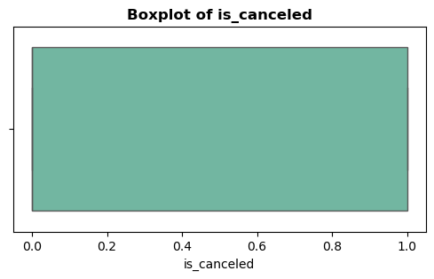

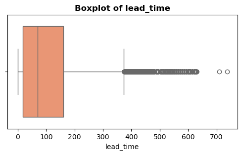

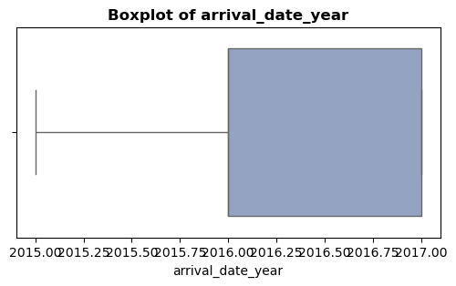

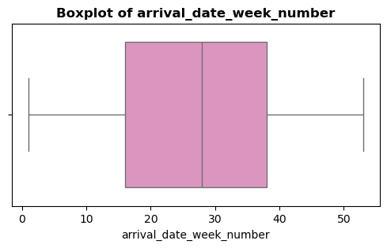

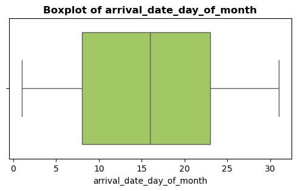

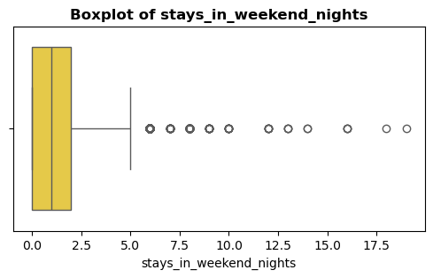

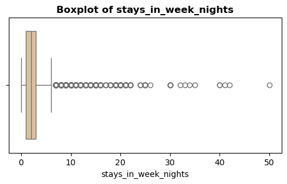

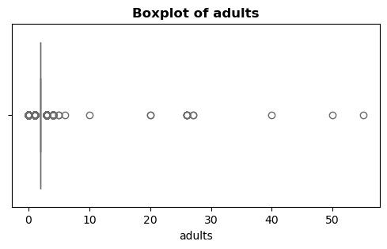

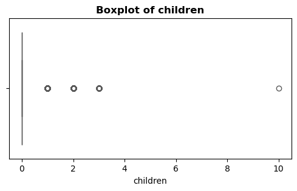

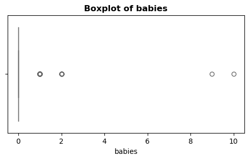

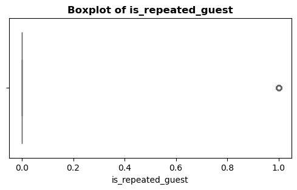

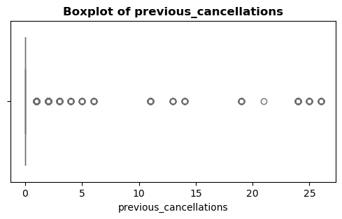

[9 more figures not shown]

```
✅ Outliers handled successfully in Hotel Booking dataset using capping!
```

```python
import pandas as pd
import numpy as np
import seaborn as sns
import matplotlib.pyplot as plt

# ===============================
# Outlier Analysis & Handling (Hotel Booking Dataset)
# ===============================

# Select only numeric columns
numerical_cols = df.select_dtypes(include=np.number).columns

# Step 1: Detect Outliers (using IQR)
outliers = {}
for col in numerical_cols:
    Q1 = df[col].quantile(0.25)
    Q3 = df[col].quantile(0.75)
    IQR = Q3 - Q1
    lower = Q1 - 1.5 * IQR
    upper = Q3 + 1.5 * IQR
    outliers[col] = df[(df[col] < lower) | (df[col] > upper)][col]
    print(f"{col}: {len(outliers[col])} outliers")

# Step 2: Visualize Outliers with Colored Boxplots
palette = sns.color_palette("Set2", len(numerical_cols))  # Different colors
for i, col in enumerate(numerical_cols):
    plt.figure(figsize=(6,3))
    sns.boxplot(x=df[col], color=palette[i])  # Apply color
    plt.title(f"Boxplot of {col}", fontsize=12, weight="bold")
    plt.show();

# Step 3: Handle Outliers by Capping (Clipping to limits)
for col in numerical_cols:
    Q1 = df[col].quantile(0.25)
    Q3 = df[col].quantile(0.75)
    IQR = Q3 - Q1
    lower = Q1 - 1.5 * IQR
    upper = Q3 + 1.5 * IQR
    df[col] = df[col].clip(lower, upper)

print("\n✅ Outliers handled successfully in Hotel Booking dataset using capping!")
```

### Column Description

| **Column Name** | **Missing Values** | **Cleaning Required** | **Importance (Why)** |
| --- | --- | --- | --- |
| hotel | 0 | No | Identifies hotel type (City/Resort) – affects booking behavior & pricing. |
| is_canceled | 0 | No | Target variable – shows if booking was cancelled. |
| lead_time | 0 | Yes (outliers) | Gap between booking & arrival – longer lead times often cancel. |
| arrival_date_year | 0 | No | Year of booking – for yearly trend analysis. |
| arrival_date_month | 0 | No | Month – captures seasonality & demand peaks. |
| stays_in_weekend_nights | 0 | No | Weekend stays – influences ADR & revenue. |
| stays_in_week_nights | 0 | No | Weekday stays – impacts occupancy levels. |
| adults | 0 | Yes (check invalid: 0 adults) | Core guest indicator – defines booking size. |
| children | Some | Yes (impute missing/invalid) | Family bookings indicator. |
| babies | 0 | No | Identifies family/child-specific bookings. |
| meal | 0 | Yes (categorical clean) | Meal plan – linked to revenue streams. |
| country | Some | Yes (missing fill) | Guest origin – domestic vs international patterns. |
| market_segment | 0 | Yes (categorical clean) | Booking channel – direct, online, corporate, etc. |
| distribution_channel | 0 | Yes (categorical clean) | Mode of booking – impacts cancellations. |
| reserved_room_type | 0 | No | Demand for specific room categories. |
| assigned_room_type | 0 | No | Room allocation & overbooking analysis. |
| deposit_type | 0 | No | Payment guarantee – affects cancellation likelihood. |
| agent | Some | Yes (missing fill / NA=none) | Booking agent – useful for partner/channel analysis. |
| company | Many missing | Yes (drop/NA=none) | Rarely filled – often not useful. |
| days_in_waiting_list | 0 | Yes (outliers) | Indicates waitlisted demand. |
| customer_type | 0 | No | Segments customers (transient, group, contract). |
| adr (Average Daily Rate) | 0 | Yes (outliers/invalid negatives) | Key revenue metric – per night per booking. |
| required_car_parking_spaces | 0 | No | Extra facilities demand. |
| total_of_special_requests | 0 | No | More requests → lower cancellation chance. |
| reservation_status | 0 | No | Final status – checked out, cancelled, or no-show. |
| reservation_status_date | 0 | Yes (convert to datetime) | Date of final status – used for cancellation timing. |